# Visualize ARIMA Model Selection

Kevin Liu

6/2/2018

# 1 Library loading

```r
library(ggplot2)
library(dplyr)
library(tidyr)
library(cowplot)
```

# 2 Beautiful ACF and PACF by `ggplot2`

Wolf yearly sunspot number is a classic time series data that have been analysis by many statisticians and scientists. In this blog, I want to emphasis on a graphic model selection method by Heiberger and Teles (2002) and Richard M. Heiberger (2015).

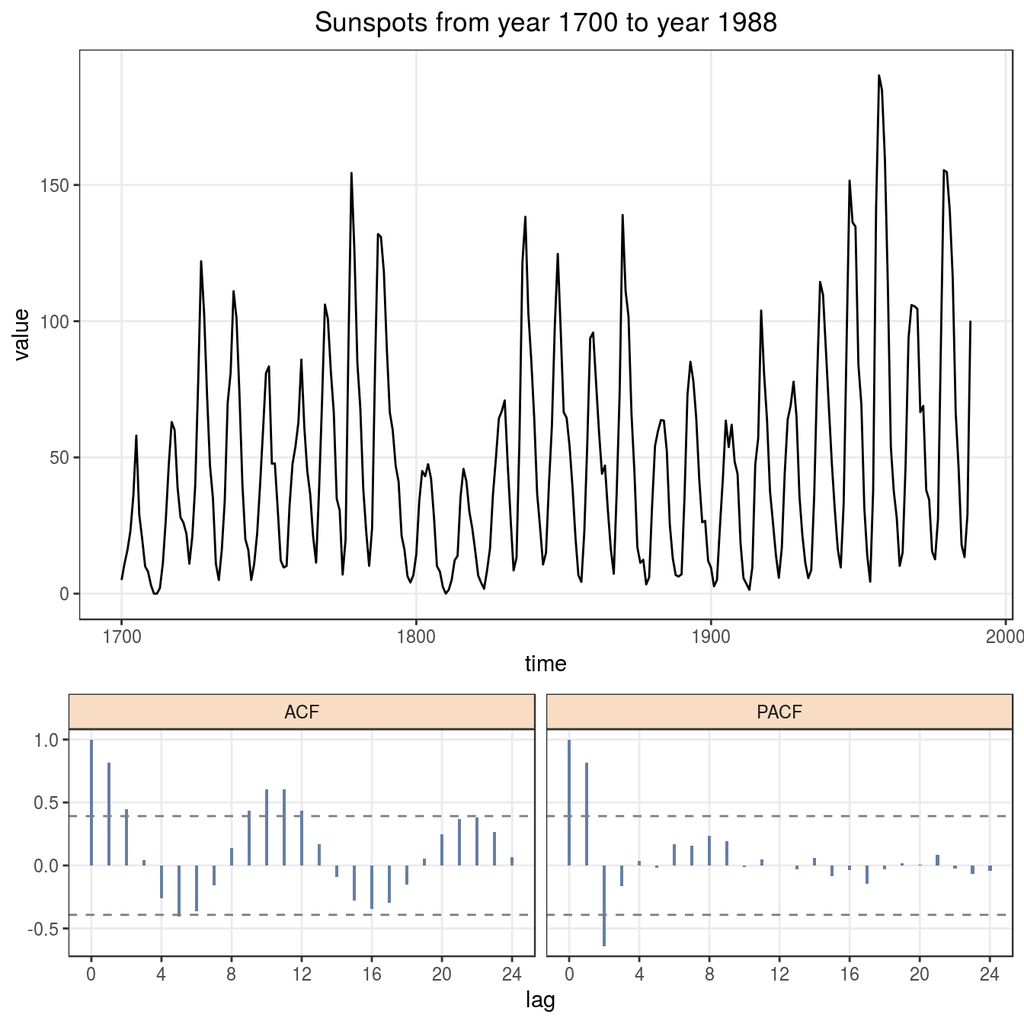

Figure 2.1: Time series plot with ACF and PACF

```r
data("sunspot.year")

arima.plot <- function(data = sunspot.year, title = "Main Title",lag.max = 24, ...) {
  if(class(data) != "ts") {stop("data must be ts")}

  df1 <- data.frame(value = as.numeric(data), time = as.numeric(time(data)))
  fig.main <- ggplot(data = df1, aes(x = time, y = value)) +
    geom_line() +
    ggtitle(title) +
    theme_bw() +
    theme(panel.grid.minor = element_blank(),
          plot.title = element_text(hjust = 0.5))

  list.acf <- acf(x = data, plot = FALSE, lag.max = lag.max)
  df.acf <- data.frame(lag = as.numeric(list.acf$lag), value = as.numeric(list.acf$acf))
  df.acf$type <- "ACF"

  list.pacf <- acf(x = data, type = "partial", plot = FALSE, lag.max = lag.max)
  df.pacf <- data.frame(lag = c(0,as.numeric(list.pacf$lag)), value = c(1,as.numeric(list.pacf$acf)))
  df.pacf$type <- "PACF"

  df.acf.pacf <- rbind.data.frame(df.acf, df.pacf)

  fig.merge <- ggplot(data = df.acf.pacf, aes( x = lag, y = value)) +
    geom_col(width = 0.2, fill = "#667fa2") +
    geom_hline(yintercept = qnorm((1+0.95)/2)/sqrt(dim(df.pacf)[1]),
               linetype = "dashed",
               colour = "grey50") +
    geom_hline(yintercept = -qnorm((1+0.95)/2)/sqrt(dim(df.pacf)[1]),
               linetype = "dashed",
               colour = "grey50") +
    scale_y_continuous(name = element_blank()) +
    scale_x_continuous(breaks = seq(0,24,4)) +
    facet_wrap(~type) +
    theme_bw() +
    theme(panel.grid.minor = element_blank(),
          strip.background = element_rect(fill = "#f8ddc4"))

  return(cowplot::plot_grid(fig.main, fig.merge, nrow = 2, rel_heights = c(2,1)))
}

arima.plot(title = "Sunspots from year 1700 to year 1988")
```

# 3 Data transformation

Using [box-cox transformation method](https://en.wikipedia.org/wiki/Power_transform), we have that $\hat{\lambda} = 0.46$. For the purpose of easy interpretation (people without statistic background will ask what does $\hat{\lambda} = 0.46$ mean), we use $\hat{\lambda} = 0.5$, which means that we should square root the original data,$\sqrt{y_{t}}$. After transformation, variance becomes smaller, ACF tails off after lag 3 and PACF cuts off after lag 2, as shown in figure 3.2. This implies that ARIMA(3,0,2) should be a appropriate model for this data.

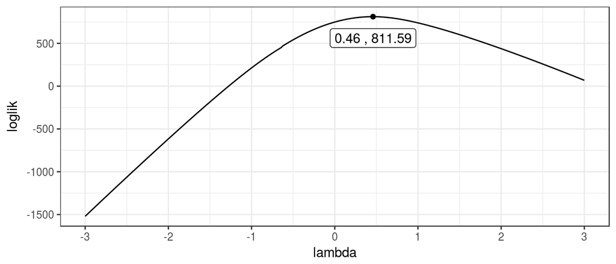

Figure 3.1: Box cox data transformation

```r
boxcox <- function(y, lambda = seq(-2, 2, 0.01), method = c("mle", "yule-walker", "burg", "ols", "yw"),...) {
  y = as.vector(y/(max(abs(y)) + 1))
  if (any(y <= 0))
    stop("y values must be positive")
  order <- ar(log(y), method = "mle")$order
  nlngmy <- sum(log(y))

  df.lambda <- data.frame(lambda = lambda)
  df.lambda.nonzero <- subset(df.lambda, lambda != 0 )
  list.var.pred <- lapply(X = t(df.lambda.nonzero$lambda), function(X) {
    ar((y^X - 1)/X,
       order.max = order,
       method = method)$var.pred
    })
  df.lambda.nonzero$var.pred <- unlist(list.var.pred)
  df.lambda.nonzero$loglik <- -length(y)/2 * log(df.lambda.nonzero$var.pred) +
    (df.lambda.nonzero$lambda - 1) * nlngmy
  df.lambda.zero <- subset(df.lambda, lambda == 0 )
  df.lambda.zero$var.pred <- ar(log(y), order.max = order, method = method)$var.pred
  df.lambda.zero$loglik <- -length(y)/2 * log(df.lambda.zero$var.pred) - nlngmy
  df.lambda <- rbind.data.frame(df.lambda.nonzero, df.lambda.zero)
  df.lambda <- df.lambda[order(df.lambda$lambda),]
  return(df.lambda)
}

df.lambda <- boxcox(y = sunspot.year + 1, lambda = seq(-3, 3, 0.01), method = "mle")
df.lambda.max <- df.lambda[df.lambda$loglik == max(df.lambda$loglik),]

ggplot(data = df.lambda, aes( x = lambda, y = loglik)) +
  geom_line() +
  geom_point( data = df.lambda.max) +
  geom_label( data = df.lambda.max, aes( x = lambda, y = loglik),
              nudge_y = -250,
              label = paste0(round(df.lambda.max$lambda,2),
                             " , ",
                             round(df.lambda.max$loglik,2))) +
  scale_x_continuous(breaks = -3:3) +
  theme_bw()
```

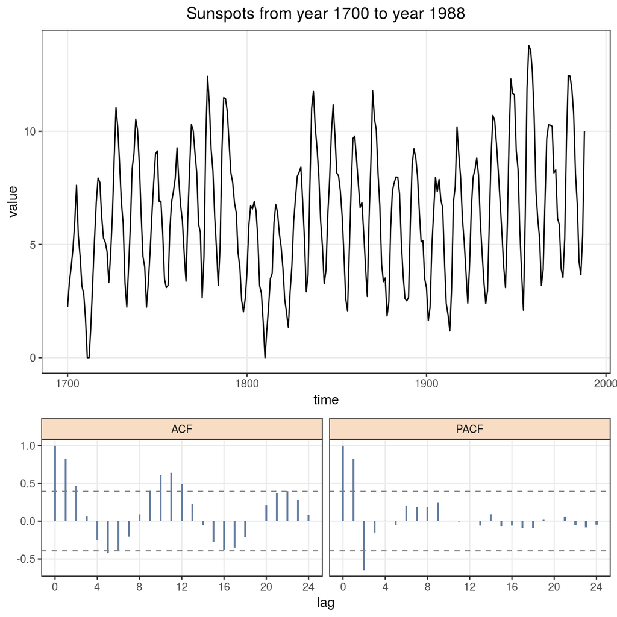

Figure 3.2: Square rooted time series with ACF and PACF

```r
sunspots.sqrt <- sqrt(sunspot.year)
arima.plot(data = sunspots.sqrt,title = "Sunspots from year 1700 to year 1988")
```

# 4 Visualized Model Comparison

The main purpose of this section is to determine which ARIMA is the most appropriate model based on residual analysis.

According to experience, for non-seasonal ARIMA mode, value of $p$ and $q$ won’t be larger than $3$. I choose $p = 3 \text{ and } q = 2$. After cartesian product of $p \in (0,1,2,3)$ and $q \in (0,1,2)$, we have $4 \times 3 = 12$ possible ARIMA models, from ARIMA(0,0,0) to ARIMA(3,0,2).

From figure 4.2, **ARIMA(3,0,0) has the smallest AIC**.

From figure 4.3, we have that results of [goodness of fit test: Box-Pierce](https://en.wikipedia.org/wiki/Ljung%E2%80%93Box_test) are very similar from ARIMA(2,0,1) to ARIMA(3,0,2).

Based all information and diagnosis we have, I feel confident to say that **ARIMA(3,0,0) is the most appropriate model** and that difference of ARIMA(2,0,1) - ARIMA(3,0,2) may not be large.

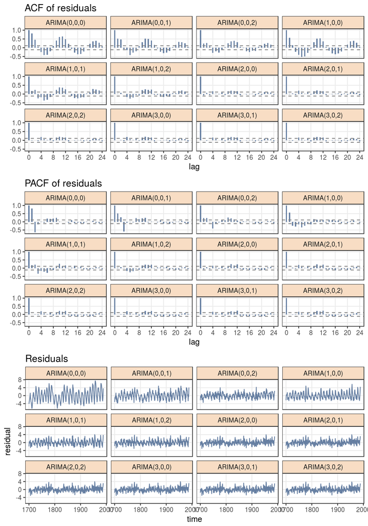

Figure 4.1: Residual diagnostics

```r
arima.order <- c(3,0,2)

p <- 0:arima.order[1]
d <- 0:arima.order[2]
q <- 0:arima.order[3]

df.arima.order <- data.frame(t(expand.grid(p=p,d=d,q=q)))
df.colnames <- data.frame(expand.grid(p=p,d=d,q=q))
df.colnames$type <- with(df.colnames,paste0("ARIMA(",p,",",d,",",q,")"))

list.arima.model <- lapply(df.arima.order,
                           function(data, x, ...) {
                             arima(x = data, order = x, ...)
                             },
                           data = sunspots.sqrt)

df.arima.residual <- sapply(list.arima.model,
                            function(x) {
                              x$residuals
                              })
df.arima.residual <- data.frame(df.arima.residual)
colnames(df.arima.residual) <- df.colnames$type
df.arima.residual$time <- time(sunspots.sqrt)

df.arima.residual.plot <- gather(data = df.arima.residual, value = "residual", key = "type",-time)

df.acf <- sapply(subset(df.arima.residual, select = -time),
       function(x, lag.max,...) {
         acf(x = x, lag.max = lag.max, plot = FALSE)$acf
       },
       lag.max = 24)
df.acf <- data.frame(df.acf)
colnames(df.acf) <- df.colnames$type

df.acf$lag <- 0:(dim(df.acf)[1]-1)
df.acf.plot <- gather(df.acf,
                      value = "value",
                      key = "Model",
                      -lag)


df.pacf <- sapply(subset(df.arima.residual, select = -time),
                  function(x, lag.max,...) {
                    acfvalue <- as.numeric(acf(x = x,
                                               lag.max = lag.max,
                                               type = "partial",
                                               plot = FALSE)$acf)
                    return(c(1,acfvalue))
                    },
                  lag.max = 24)
df.pacf <- data.frame(df.pacf)
colnames(df.pacf) <- df.colnames$type

df.pacf$lag <- 0:(dim(df.pacf)[1]-1)
df.pacf.plot <- gather(df.pacf,
                       value = "value",
                       key = "Model",
                       -lag)

fig.acf <- ggplot(data = df.acf.plot, aes(x = lag, y = value)) +
  geom_col(width = 0.4, fill = "#667fa2") +
  geom_hline(yintercept = qnorm((1+0.95)/2)/sqrt(dim(df.acf.plot)[1]),
             linetype = "dashed",
             colour = "grey50") +
  geom_hline(yintercept = -qnorm((1+0.95)/2)/sqrt(dim(df.acf.plot)[1]),
             linetype = "dashed",
             colour = "grey50") +
  scale_y_continuous(name = element_blank()) +
  scale_x_continuous(breaks = seq(0,24,4)) +
  ggtitle("ACF of residuals") +
  facet_wrap(~Model) +
  theme_bw() +
  theme(panel.grid.minor = element_blank(),
        strip.background = element_rect(fill = "#f8ddc4"))

fig.pacf <- ggplot(data = df.pacf.plot, aes(x = lag, y = value)) +
  geom_col(width = 0.4, fill = "#667fa2") +
  geom_hline(yintercept = qnorm((1+0.95)/2)/sqrt(dim(df.pacf.plot)[1]),
             linetype = "dashed",
             colour = "grey50") +
  geom_hline(yintercept = -qnorm((1+0.95)/2)/sqrt(dim(df.pacf.plot)[1]),
             linetype = "dashed",
             colour = "grey50") +
  scale_y_continuous(name = element_blank()) +
  scale_x_continuous(breaks = seq(0,24,4)) +
  ggtitle("PACF of residuals") +
  facet_wrap(~Model) +
  theme_bw() +
  theme(panel.grid.minor = element_blank(),
        strip.background = element_rect(fill = "#f8ddc4"))

fig.residual <- ggplot(data = df.arima.residual.plot, aes(x = time, y = residual)) +
  geom_line(colour = "#667fa2") +
  ggtitle("Residuals") +
  facet_wrap(~type) +
  theme_bw() +
  theme(panel.grid.minor = element_blank(),
        strip.background = element_rect(fill = "#f8ddc4"))

cowplot::plot_grid(fig.acf, fig.pacf, fig.residual, nrow = 3)
```

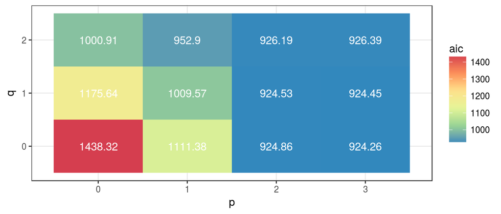

Figure 4.2: Information criteria

```r
aic <- sapply(list.arima.model, function(X) {X$aic})
aic <- round(as.numeric(aic),2)
df.aic.plot <- data.frame(aic = aic, p = df.colnames$p, q = df.colnames$q)

ggplot(data = df.aic.plot, aes(x = p, y = q)) +
  geom_raster(aes(fill = aic)) +
  geom_text(aes( label = aic), colour = "white") +
  scale_x_continuous(expand = c(0.05,0.05)) +
  scale_color_continuous( high = "#FFA800", low = "#4AC200") +
  theme_bw() +
  theme(panel.grid.minor = element_blank()) +
  scale_fill_distiller(palette = "Spectral", direction = -1)
```

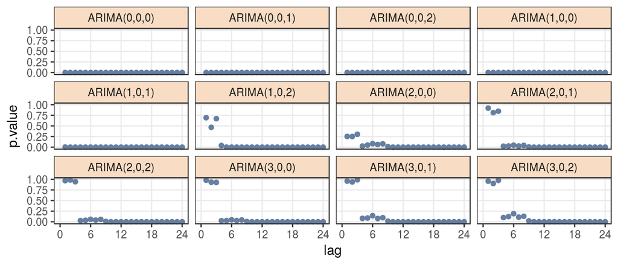

Figure 4.3: Goodness of fit:Box-Pierce

```r
df.box.test <- sapply(list.arima.model, function(x) {
  residuals <- x$residuals
  df.lag <- data.frame(t(1:24))
  as.numeric(sapply(df.lag, function(maxlag) {
  pvalues <- Box.test(x = residuals, lag = maxlag)$p.value
  return(pvalues)
}))
})

df.box.test <- as.data.frame(df.box.test)
colnames(df.box.test) <- df.colnames$type
df.box.test$lag <- 1:24

df.box.test <- gather(df.box.test, value = "p.value", key = "model.type", -lag)

ggplot(data = df.box.test, aes(x = lag, y = p.value)) +
  geom_point(colour = "#667fa2") +
  facet_wrap(~model.type) +
  scale_x_continuous(limits = c(0,24), breaks = seq(0,24,6)) +
  theme_bw() +
  theme(panel.grid.minor = element_blank(),
        strip.background = element_rect(fill = "#f8ddc4"))
```

# References

Richard M. Heiberger (2015) Heiberger and Teles (2002) Wei (1990)

Heiberger, Richard M, and Paulo Teles. 2002. “Displays for Direct Comparison of Arima Models.” *The American Statistician* 56 (2). Taylor & Francis: 131–38. doi:10.1198/000313002317572808.

Richard M. Heiberger, Burt Holland. 2015. *Statistical Analysis and Data Display an Intermediate Course with Examples in R*. Second Edition.

Wei, William. 1990. *Time Series Analysis: Univariate and Multivariate Methods*. Second Edition.